# Keras_RNN_IMDB_3

```python
import keras
from keras.datasets import imdb
```

```python
max_features = 10000 #max number of words in vocab
maxlen = 500         #cut off text after this many words
batch_size = 32
print('Loading data...')
(input_train, y_train), (input_test, y_test) = imdb.load_data(num_words=max_features)
```

```
Loading data...
```

```python
print(len(input_train), 'train sequences')
print(len(input_test), 'test sequences')
print('Pad sequences (samples x time)')
```

```
25000 train sequences
25000 test sequences
Pad sequences (samples x time)
```

Suppose we have text message with 5 reviews.say i review is 300 characters,other 2 review is 500 characters,rest other say 550,525 characters.now if we give max len as 300 then rest other will be padded with zeroes.in case of a review with 550,we will be losing much data.if we choose max len as 300.so we need to choose maxlen carefully.so above we should choose maxlen as 500 instead of 300 so that data is not lost from arrays of reviews.

```python
input_train = keras.utils.pad_sequences(input_train, maxlen=maxlen)
input_test = keras.utils.pad_sequences(input_test, maxlen=maxlen)
print('input_train shape:', input_train.shape)
print('input_test shape:', input_test.shape)
```

```
input_train shape: (25000, 500)
input_test shape: (25000, 500)
```

```python
print(input_train[0])
```

```
[   0    0    0    0    0    0    0    0    0    0    0    0    0    0
    0    0    0    0    0    0    0    0    0    0    0    0    0    0
    0    0    0    0    0    0    0    0    0    0    0    0    0    0
    0    0    0    0    0    0    0    0    0    0    0    0    0    0
    0    0    0    0    0    0    0    0    0    0    0    0    0    0
    0    0    0    0    0    0    0    0    0    0    0    0    0    0
    0    0    0    0    0    0    0    0    0    0    0    0    0    0
    0    0    0    0    0    0    0    0    0    0    0    0    0    0
    0    0    0    0    0    0    0    0    0    0    0    0    0    0
    0    0    0    0    0    0    0    0    0    0    0    0    0    0
    0    0    0    0    0    0    0    0    0    0    0    0    0    0
    0    0    0    0    0    0    0    0    0    0    0    0    0    0
    0    0    0    0    0    0    0    0    0    0    0    0    0    0
    0    0    0    0    0    0    0    0    0    0    0    0    0    0
    0    0    0    0    0    0    0    0    0    0    0    0    0    0
```

[output cut: 21 more lines]

```python
print(input_test[0])
```

```
[   0    0    0    0    0    0    0    0    0    0    0    0    0    0
    0    0    0    0    0    0    0    0    0    0    0    0    0    0
    0    0    0    0    0    0    0    0    0    0    0    0    0    0
    0    0    0    0    0    0    0    0    0    0    0    0    0    0
    0    0    0    0    0    0    0    0    0    0    0    0    0    0
    0    0    0    0    0    0    0    0    0    0    0    0    0    0
    0    0    0    0    0    0    0    0    0    0    0    0    0    0
    0    0    0    0    0    0    0    0    0    0    0    0    0    0
    0    0    0    0    0    0    0    0    0    0    0    0    0    0
    0    0    0    0    0    0    0    0    0    0    0    0    0    0
    0    0    0    0    0    0    0    0    0    0    0    0    0    0
    0    0    0    0    0    0    0    0    0    0    0    0    0    0
    0    0    0    0    0    0    0    0    0    0    0    0    0    0
    0    0    0    0    0    0    0    0    0    0    0    0    0    0
    0    0    0    0    0    0    0    0    0    0    0    0    0    0
```

[output cut: 21 more lines]

embedding layer will create a word vector and while training the deep learning model it will also train the word vector so every word will convert to a word vector.here in vector max feature is number of word that is present.here it is 10000 as mentioned above in the code and each word will become a vector of 32 size as shown below:model.add(Embedding(max_features, 32)).we limit ourself to keep the vector size as 16 or 32.we can even keep the vector size as 128 or even 256 for a very large dataset.but that may become a time consuming process while building the deep learning models.

The reason why we convert each word into a word vector before training a deep learning model is because that will improve the training and validation accuracy.

```python
from keras.models import Sequential
from keras.layers import Embedding, SimpleRNN
from keras.layers import Dense
model = Sequential()
model.add(Embedding(max_features, 32))    #here we are using word vector in place of multi-hot encoding done in chapter04_getting-started-with-neural-networks.ipynb
model.add(SimpleRNN(32))
model.add(Dense(1, activation='sigmoid'))
model.compile(optimizer='rmsprop', loss='binary_crossentropy', metrics=['acc'])
history = model.fit(input_train, y_train,epochs=10,batch_size=128,validation_split=0.2)
```

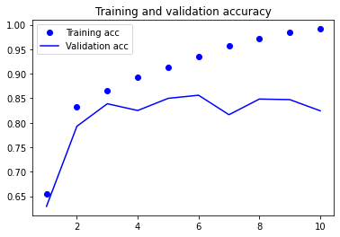

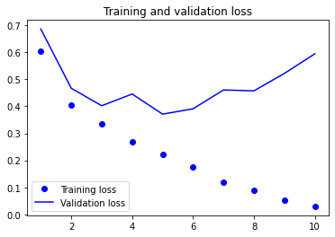

```python
import matplotlib.pyplot as plt
acc = history.history['acc']
val_acc = history.history['val_acc']
loss = history.history['loss']
val_loss = history.history['val_loss']
epochs = range(1, len(acc) + 1)
plt.plot(epochs, acc, 'bo', label='Training acc')
plt.plot(epochs, val_acc, 'b', label='Validation acc')
plt.title('Training and validation accuracy')
plt.legend()
plt.figure()
plt.plot(epochs, loss, 'bo', label='Training loss')
plt.plot(epochs, val_loss, 'b', label='Validation loss')
plt.title('Training and validation loss')
plt.legend()
plt.show()
```

```python
!jupyter nbconvert Keras_RNN_IMDB_3.ipynb
```

```
[NbConvertApp] Converting notebook Keras_RNN_IMDB_3.ipynb to html
[NbConvertApp] Writing 326410 bytes to Keras_RNN_IMDB_3.html
```